# Risk Factor Analysis

## Outcome Variable

**Outcome Variable:** wasted

## Predictor Variables

**Intervention Variable:** predfeed36

**Adjustment Set:**

- arm
- sex
- month
- brthmon
- W_mage
- meducyrs
- feducyrs
- hhwealth_quart
- hfoodsec
- W_mhtcm
- vagbrth
- W_gagebrth
- W_birthwt
- W_birthlen
- W_nrooms
- W_nchldlt5
- W_parity
- impfloor
- impsan
- safeh20
- delta_W_mage
- delta_meducyrs
- delta_feducyrs
- delta_hhwealth_quart
- delta_hfoodsec
- delta_W_mhtcm
- delta_vagbrth
- delta_W_gagebrth
- delta_W_birthwt
- delta_W_birthlen
- delta_W_nrooms
- delta_W_nchldlt5
- delta_W_parity
- delta_impfloor
- delta_impsan
- delta_safeh20

## Stratifying Variables

The analysis was stratified on these variable(s):

- agecat
- studyid
- country

## Data Summary

| agecat | studyid | country | predfeed36 | wasted | n_cell | n |
| --- | --- | --- | --- | --- | --- | --- |
| Birth | ki0047075b-MAL-ED | BANGLADESH | 1 | 0 | 102 | 230 |
| Birth | ki0047075b-MAL-ED | BANGLADESH | 1 | 1 | 18 | 230 |
| Birth | ki0047075b-MAL-ED | BANGLADESH | 0 | 0 | 89 | 230 |
| Birth | ki0047075b-MAL-ED | BANGLADESH | 0 | 1 | 21 | 230 |
| Birth | ki0047075b-MAL-ED | BRAZIL | 1 | 0 | 28 | 177 |
| Birth | ki0047075b-MAL-ED | BRAZIL | 1 | 1 | 0 | 177 |
| Birth | ki0047075b-MAL-ED | BRAZIL | 0 | 0 | 143 | 177 |
| Birth | ki0047075b-MAL-ED | BRAZIL | 0 | 1 | 6 | 177 |
| Birth | ki0047075b-MAL-ED | INDIA | 1 | 0 | 14 | 195 |
| Birth | ki0047075b-MAL-ED | INDIA | 1 | 1 | 2 | 195 |
| Birth | ki0047075b-MAL-ED | INDIA | 0 | 0 | 148 | 195 |
| Birth | ki0047075b-MAL-ED | INDIA | 0 | 1 | 31 | 195 |
| Birth | ki0047075b-MAL-ED | NEPAL | 1 | 0 | 24 | 167 |
| Birth | ki0047075b-MAL-ED | NEPAL | 1 | 1 | 1 | 167 |
| Birth | ki0047075b-MAL-ED | NEPAL | 0 | 0 | 123 | 167 |
| Birth | ki0047075b-MAL-ED | NEPAL | 0 | 1 | 19 | 167 |
| Birth | ki0047075b-MAL-ED | PERU | 1 | 0 | 115 | 266 |
| Birth | ki0047075b-MAL-ED | PERU | 1 | 1 | 1 | 266 |
| Birth | ki0047075b-MAL-ED | PERU | 0 | 0 | 145 | 266 |
| Birth | ki0047075b-MAL-ED | PERU | 0 | 1 | 5 | 266 |
| Birth | ki0047075b-MAL-ED | SOUTH AFRICA | 1 | 0 | 3 | 234 |
| Birth | ki0047075b-MAL-ED | SOUTH AFRICA | 1 | 1 | 0 | 234 |
| Birth | ki0047075b-MAL-ED | SOUTH AFRICA | 0 | 0 | 217 | 234 |
| Birth | ki0047075b-MAL-ED | SOUTH AFRICA | 0 | 1 | 14 | 234 |
| Birth | ki0047075b-MAL-ED | TANZANIA, UNITED REPUBLIC OF | 1 | 0 | 1 | 116 |
| Birth | ki0047075b-MAL-ED | TANZANIA, UNITED REPUBLIC OF | 1 | 1 | 0 | 116 |
| Birth | ki0047075b-MAL-ED | TANZANIA, UNITED REPUBLIC OF | 0 | 0 | 113 | 116 |
| Birth | ki0047075b-MAL-ED | TANZANIA, UNITED REPUBLIC OF | 0 | 1 | 2 | 116 |
| Birth | ki1000109-EE | PAKISTAN | 1 | 0 | 0 | 1 |
| Birth | ki1000109-EE | PAKISTAN | 1 | 1 | 0 | 1 |

[output cut: 106 more lines]

The following strata were considered:

- agecat: 24 months, studyid: ki0047075b-MAL-ED, country: BANGLADESH
- agecat: 24 months, studyid: ki0047075b-MAL-ED, country: BRAZIL
- agecat: 24 months, studyid: ki0047075b-MAL-ED, country: INDIA
- agecat: 24 months, studyid: ki0047075b-MAL-ED, country: NEPAL
- agecat: 24 months, studyid: ki0047075b-MAL-ED, country: PERU
- agecat: 24 months, studyid: ki0047075b-MAL-ED, country: SOUTH AFRICA
- agecat: 24 months, studyid: ki0047075b-MAL-ED, country: TANZANIA, UNITED REPUBLIC OF
- agecat: 24 months, studyid: ki1113344-GMS-Nepal, country: NEPAL
- agecat: 24 months, studyid: ki1148112-LCNI-5, country: MALAWI
- agecat: 24 months, studyid: kiGH5241-JiVitA-3, country: BANGLADESH
- agecat: 24 months, studyid: kiGH5241-JiVitA-4, country: BANGLADESH
- agecat: 6 months, studyid: ki0047075b-MAL-ED, country: BANGLADESH
- agecat: 6 months, studyid: ki0047075b-MAL-ED, country: BRAZIL
- agecat: 6 months, studyid: ki0047075b-MAL-ED, country: INDIA
- agecat: 6 months, studyid: ki0047075b-MAL-ED, country: NEPAL
- agecat: 6 months, studyid: ki0047075b-MAL-ED, country: PERU
- agecat: 6 months, studyid: ki0047075b-MAL-ED, country: SOUTH AFRICA
- agecat: 6 months, studyid: ki0047075b-MAL-ED, country: TANZANIA, UNITED REPUBLIC OF
- agecat: 6 months, studyid: ki1000109-EE, country: PAKISTAN
- agecat: 6 months, studyid: ki1000304b-SAS-FoodSuppl, country: INDIA
- agecat: 6 months, studyid: ki1113344-GMS-Nepal, country: NEPAL
- agecat: 6 months, studyid: ki1148112-LCNI-5, country: MALAWI
- agecat: 6 months, studyid: kiGH5241-JiVitA-3, country: BANGLADESH
- agecat: 6 months, studyid: kiGH5241-JiVitA-4, country: BANGLADESH
- agecat: Birth, studyid: ki0047075b-MAL-ED, country: BANGLADESH
- agecat: Birth, studyid: ki0047075b-MAL-ED, country: BRAZIL
- agecat: Birth, studyid: ki0047075b-MAL-ED, country: INDIA
- agecat: Birth, studyid: ki0047075b-MAL-ED, country: NEPAL
- agecat: Birth, studyid: ki0047075b-MAL-ED, country: PERU
- agecat: Birth, studyid: ki0047075b-MAL-ED, country: SOUTH AFRICA
- agecat: Birth, studyid: ki0047075b-MAL-ED, country: TANZANIA, UNITED REPUBLIC OF
- agecat: Birth, studyid: ki1000109-EE, country: PAKISTAN
- agecat: Birth, studyid: kiGH5241-JiVitA-3, country: BANGLADESH
- agecat: Birth, studyid: kiGH5241-JiVitA-4, country: BANGLADESH

### Dropped Strata

Some strata were dropped due to rare outcomes:

- agecat: Birth, studyid: ki0047075b-MAL-ED, country: BRAZIL
- agecat: Birth, studyid: ki0047075b-MAL-ED, country: INDIA
- agecat: Birth, studyid: ki0047075b-MAL-ED, country: NEPAL
- agecat: Birth, studyid: ki0047075b-MAL-ED, country: PERU
- agecat: Birth, studyid: ki0047075b-MAL-ED, country: SOUTH AFRICA
- agecat: Birth, studyid: ki0047075b-MAL-ED, country: TANZANIA, UNITED REPUBLIC OF
- agecat: Birth, studyid: ki1000109-EE, country: PAKISTAN
- agecat: Birth, studyid: kiGH5241-JiVitA-4, country: BANGLADESH
- agecat: 6 months, studyid: ki0047075b-MAL-ED, country: BANGLADESH
- agecat: 6 months, studyid: ki0047075b-MAL-ED, country: BRAZIL
- agecat: 6 months, studyid: ki0047075b-MAL-ED, country: INDIA
- agecat: 6 months, studyid: ki0047075b-MAL-ED, country: NEPAL
- agecat: 6 months, studyid: ki0047075b-MAL-ED, country: PERU
- agecat: 6 months, studyid: ki0047075b-MAL-ED, country: SOUTH AFRICA
- agecat: 6 months, studyid: ki0047075b-MAL-ED, country: TANZANIA, UNITED REPUBLIC OF
- agecat: 6 months, studyid: ki1000304b-SAS-FoodSuppl, country: INDIA
- agecat: 6 months, studyid: ki1148112-LCNI-5, country: MALAWI
- agecat: 24 months, studyid: ki0047075b-MAL-ED, country: BRAZIL
- agecat: 24 months, studyid: ki0047075b-MAL-ED, country: INDIA
- agecat: 24 months, studyid: ki0047075b-MAL-ED, country: NEPAL
- agecat: 24 months, studyid: ki0047075b-MAL-ED, country: PERU
- agecat: 24 months, studyid: ki0047075b-MAL-ED, country: SOUTH AFRICA
- agecat: 24 months, studyid: ki0047075b-MAL-ED, country: TANZANIA, UNITED REPUBLIC OF
- agecat: 24 months, studyid: ki1148112-LCNI-5, country: MALAWI

## Methods Detail

We’re interested in the causal parameters $E[Y_a]$ for all values of $a \in \mathcal{A}$. These parameters represent the mean outcome if, possibly contrary to fact, we intervened to set all units to have $A=a$. Under the randomization and positivity assumptions, these are identified by the statistical parameters $\psi_a=E_W[E_{Y|A,W}(Y|A=a,W)]$. In addition, we’re interested in the mean of $Y$, $E[Y]$ under no intervention (the observed mean). We will estimate these parameters by using SuperLearner to fit the relevant likelihood factors – $E_{Y|A,W}(Y|A=a,W)$ and $p(A=a|W)$, and then updating our likelihood fit using a joint TMLE.

For unadjusted analyses ($W=\{\}$), initial likelihoods were estimated using Lrnr_glm to estimate the simple $E(Y|A)$ and Lrnr_mean to estimate $p(A)$. For adjusted analyses, a small library containing Lrnr_glmnet, Lrnr_xgboost, and Lrnr_mean was used.

Having estimated these parameters, we will then use the delta method to estimate relative risks and attributable risks relative to a prespecified baseline level of $A$.

# Results Detail

## Results Plots

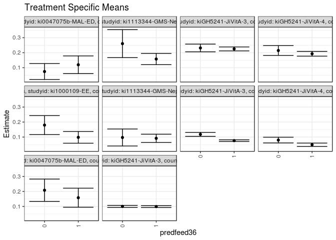

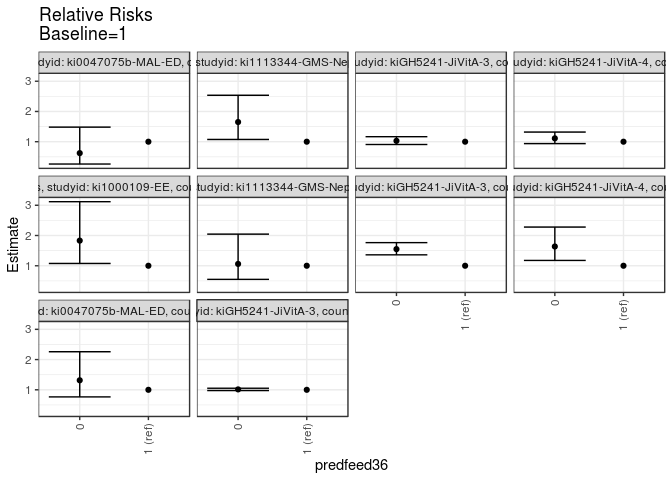

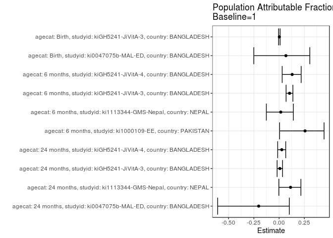

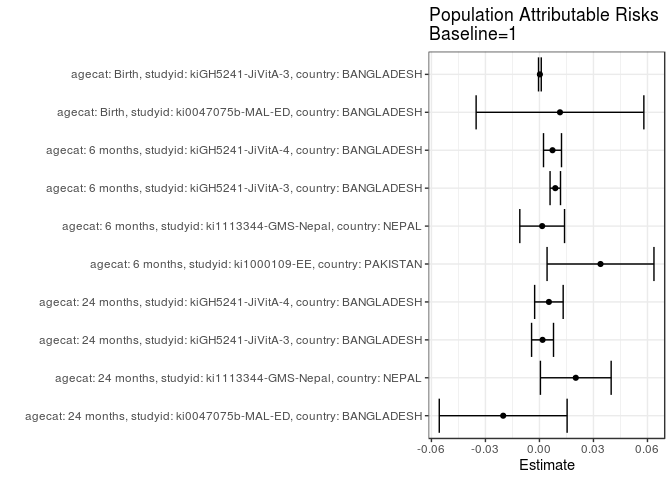

## Results Table

### Parameter: TSM

| agecat | studyid | country | intervention_level | baseline_level | estimate | ci_lower | ci_upper |
| --- | --- | --- | --- | --- | --- | --- | --- |
| Birth | ki0047075b-MAL-ED | BANGLADESH | 1 | NA | 0.1581517 | 0.0946775 | 0.2216258 |
| Birth | ki0047075b-MAL-ED | BANGLADESH | 0 | NA | 0.2079522 | 0.1335044 | 0.2824001 |
| Birth | kiGH5241-JiVitA-3 | BANGLADESH | 1 | NA | 0.0989617 | 0.0926997 | 0.1052238 |
| Birth | kiGH5241-JiVitA-3 | BANGLADESH | 0 | NA | 0.1003042 | 0.0933696 | 0.1072389 |
| 6 months | ki1000109-EE | PAKISTAN | 1 | NA | 0.0981524 | 0.0589920 | 0.1373129 |
| 6 months | ki1000109-EE | PAKISTAN | 0 | NA | 0.1797550 | 0.1165501 | 0.2429599 |
| 6 months | ki1113344-GMS-Nepal | NEPAL | 1 | NA | 0.0916361 | 0.0641799 | 0.1190923 |
| 6 months | ki1113344-GMS-Nepal | NEPAL | 0 | NA | 0.0971907 | 0.0405161 | 0.1538653 |
| 6 months | kiGH5241-JiVitA-3 | BANGLADESH | 1 | NA | 0.0761995 | 0.0706051 | 0.0817940 |
| 6 months | kiGH5241-JiVitA-3 | BANGLADESH | 0 | NA | 0.1181006 | 0.1049385 | 0.1312626 |
| 6 months | kiGH5241-JiVitA-4 | BANGLADESH | 1 | NA | 0.0488317 | 0.0377275 | 0.0599359 |
| 6 months | kiGH5241-JiVitA-4 | BANGLADESH | 0 | NA | 0.0799358 | 0.0609088 | 0.0989628 |
| 24 months | ki0047075b-MAL-ED | BANGLADESH | 1 | NA | 0.1196581 | 0.0607082 | 0.1786081 |
| 24 months | ki0047075b-MAL-ED | BANGLADESH | 0 | NA | 0.0744681 | 0.0212699 | 0.1276662 |
| 24 months | ki1113344-GMS-Nepal | NEPAL | 1 | NA | 0.1578338 | 0.1204472 | 0.1952205 |
| 24 months | ki1113344-GMS-Nepal | NEPAL | 0 | NA | 0.2605301 | 0.1672925 | 0.3537676 |
| 24 months | kiGH5241-JiVitA-3 | BANGLADESH | 1 | NA | 0.2253448 | 0.2122362 | 0.2384534 |
| 24 months | kiGH5241-JiVitA-3 | BANGLADESH | 0 | NA | 0.2317176 | 0.2060509 | 0.2573843 |
| 24 months | kiGH5241-JiVitA-4 | BANGLADESH | 1 | NA | 0.1930445 | 0.1771309 | 0.2089581 |
| 24 months | kiGH5241-JiVitA-4 | BANGLADESH | 0 | NA | 0.2146381 | 0.1817101 | 0.2475661 |

### Parameter: E(Y)

| agecat | studyid | country | intervention_level | baseline_level | estimate | ci_lower | ci_upper |
| --- | --- | --- | --- | --- | --- | --- | --- |
| Birth | ki0047075b-MAL-ED | BANGLADESH | NA | NA | 0.1695652 | 0.1209635 | 0.2181669 |
| Birth | kiGH5241-JiVitA-3 | BANGLADESH | NA | NA | 0.0992137 | 0.0929975 | 0.1054299 |
| 6 months | ki1000109-EE | PAKISTAN | NA | NA | 0.1320755 | 0.0975770 | 0.1665739 |
| 6 months | ki1113344-GMS-Nepal | NEPAL | NA | NA | 0.0931559 | 0.0682937 | 0.1180181 |
| 6 months | kiGH5241-JiVitA-3 | BANGLADESH | NA | NA | 0.0849996 | 0.0797287 | 0.0902706 |
| 6 months | kiGH5241-JiVitA-4 | BANGLADESH | NA | NA | 0.0560882 | 0.0466363 | 0.0655401 |
| 24 months | ki0047075b-MAL-ED | BANGLADESH | NA | NA | 0.0995261 | 0.0590366 | 0.1400156 |
| 24 months | ki1113344-GMS-Nepal | NEPAL | NA | NA | 0.1780220 | 0.1428346 | 0.2132094 |
| 24 months | kiGH5241-JiVitA-3 | BANGLADESH | NA | NA | 0.2270683 | 0.2155455 | 0.2385912 |
| 24 months | kiGH5241-JiVitA-4 | BANGLADESH | NA | NA | 0.1983038 | 0.1835884 | 0.2130192 |

### Parameter: RR

| agecat | studyid | country | intervention_level | baseline_level | estimate | ci_lower | ci_upper |
| --- | --- | --- | --- | --- | --- | --- | --- |
| Birth | ki0047075b-MAL-ED | BANGLADESH | 1 | 1 | 1.0000000 | 1.0000000 | 1.000000 |
| Birth | ki0047075b-MAL-ED | BANGLADESH | 0 | 1 | 1.3148910 | 0.7652477 | 2.259319 |
| Birth | kiGH5241-JiVitA-3 | BANGLADESH | 1 | 1 | 1.0000000 | 1.0000000 | 1.000000 |
| Birth | kiGH5241-JiVitA-3 | BANGLADESH | 0 | 1 | 1.0135660 | 0.9760393 | 1.052536 |
| 6 months | ki1000109-EE | PAKISTAN | 1 | 1 | 1.0000000 | 1.0000000 | 1.000000 |
| 6 months | ki1000109-EE | PAKISTAN | 0 | 1 | 1.8313854 | 1.0753718 | 3.118896 |
| 6 months | ki1113344-GMS-Nepal | NEPAL | 1 | 1 | 1.0000000 | 1.0000000 | 1.000000 |
| 6 months | ki1113344-GMS-Nepal | NEPAL | 0 | 1 | 1.0606158 | 0.5498397 | 2.045880 |
| 6 months | kiGH5241-JiVitA-3 | BANGLADESH | 1 | 1 | 1.0000000 | 1.0000000 | 1.000000 |
| 6 months | kiGH5241-JiVitA-3 | BANGLADESH | 0 | 1 | 1.5498859 | 1.3608924 | 1.765126 |
| 6 months | kiGH5241-JiVitA-4 | BANGLADESH | 1 | 1 | 1.0000000 | 1.0000000 | 1.000000 |
| 6 months | kiGH5241-JiVitA-4 | BANGLADESH | 0 | 1 | 1.6369659 | 1.1756081 | 2.279380 |
| 24 months | ki0047075b-MAL-ED | BANGLADESH | 1 | 1 | 1.0000000 | 1.0000000 | 1.000000 |
| 24 months | ki0047075b-MAL-ED | BANGLADESH | 0 | 1 | 0.6223404 | 0.2613104 | 1.482174 |
| 24 months | ki1113344-GMS-Nepal | NEPAL | 1 | 1 | 1.0000000 | 1.0000000 | 1.000000 |
| 24 months | ki1113344-GMS-Nepal | NEPAL | 0 | 1 | 1.6506603 | 1.0744230 | 2.535947 |
| 24 months | kiGH5241-JiVitA-3 | BANGLADESH | 1 | 1 | 1.0000000 | 1.0000000 | 1.000000 |
| 24 months | kiGH5241-JiVitA-3 | BANGLADESH | 0 | 1 | 1.0282801 | 0.9071800 | 1.165546 |
| 24 months | kiGH5241-JiVitA-4 | BANGLADESH | 1 | 1 | 1.0000000 | 1.0000000 | 1.000000 |
| 24 months | kiGH5241-JiVitA-4 | BANGLADESH | 0 | 1 | 1.1118581 | 0.9374562 | 1.318705 |

### Parameter: PAR

| agecat | studyid | country | intervention_level | baseline_level | estimate | ci_lower | ci_upper |
| --- | --- | --- | --- | --- | --- | --- | --- |
| Birth | ki0047075b-MAL-ED | BANGLADESH | 1 | NA | 0.0114135 | -0.0351669 | 0.0579940 |
| Birth | kiGH5241-JiVitA-3 | BANGLADESH | 1 | NA | 0.0002520 | -0.0005060 | 0.0010099 |
| 6 months | ki1000109-EE | PAKISTAN | 1 | NA | 0.0339230 | 0.0042383 | 0.0636078 |
| 6 months | ki1113344-GMS-Nepal | NEPAL | 1 | NA | 0.0015198 | -0.0109023 | 0.0139419 |
| 6 months | kiGH5241-JiVitA-3 | BANGLADESH | 1 | NA | 0.0088001 | 0.0058987 | 0.0117015 |
| 6 months | kiGH5241-JiVitA-4 | BANGLADESH | 1 | NA | 0.0072565 | 0.0022593 | 0.0122537 |
| 24 months | ki0047075b-MAL-ED | BANGLADESH | 1 | NA | -0.0201321 | -0.0556369 | 0.0153728 |
| 24 months | ki1113344-GMS-Nepal | NEPAL | 1 | NA | 0.0201881 | 0.0005427 | 0.0398336 |
| 24 months | kiGH5241-JiVitA-3 | BANGLADESH | 1 | NA | 0.0017235 | -0.0043689 | 0.0078160 |
| 24 months | kiGH5241-JiVitA-4 | BANGLADESH | 1 | NA | 0.0052593 | -0.0026643 | 0.0131829 |

### Parameter: PAF

| agecat | studyid | country | intervention_level | baseline_level | estimate | ci_lower | ci_upper |
| --- | --- | --- | --- | --- | --- | --- | --- |
| Birth | ki0047075b-MAL-ED | BANGLADESH | 1 | NA | 0.0673106 | -0.2501604 | 0.3041617 |
| Birth | kiGH5241-JiVitA-3 | BANGLADESH | 1 | NA | 0.0025397 | -0.0051309 | 0.0101518 |
| 6 months | ki1000109-EE | PAKISTAN | 1 | NA | 0.2568458 | 0.0048143 | 0.4450501 |
| 6 months | ki1113344-GMS-Nepal | NEPAL | 1 | NA | 0.0163146 | -0.1264246 | 0.1409660 |
| 6 months | kiGH5241-JiVitA-3 | BANGLADESH | 1 | NA | 0.1035310 | 0.0691836 | 0.1366110 |
| 6 months | kiGH5241-JiVitA-4 | BANGLADESH | 1 | NA | 0.1293768 | 0.0304280 | 0.2182274 |
| 24 months | ki0047075b-MAL-ED | BANGLADESH | 1 | NA | -0.2022792 | -0.6081499 | 0.1011564 |
| 24 months | ki1113344-GMS-Nepal | NEPAL | 1 | NA | 0.1134025 | -0.0025269 | 0.2159261 |
| 24 months | kiGH5241-JiVitA-3 | BANGLADESH | 1 | NA | 0.0075904 | -0.0196148 | 0.0340697 |
| 24 months | kiGH5241-JiVitA-4 | BANGLADESH | 1 | NA | 0.0265215 | -0.0140875 | 0.0655042 |